# 1. blockCV introduction: how to create block cross-validation folds

Roozbeh Valavi

2026-09-28

## Introduction

The package `blockCV` offers a range of functions for generating train and test folds for **k-fold** and **leave-one-out (LOO)** cross-validation (CV). It allows for separation of data spatially, environmentally, by nearest-neighbour distance matching, or by user-defined groups. The `blockCV` package is suitable for the evaluation of a variety of spatial modelling applications, including classification of remote sensing imagery, soil mapping, and species distribution modelling (SDM). It also provides support for different SDM scenarios, including presence-absence and presence-background species data, rare and common species, and raster data for predictor variables.

This tutorial demonstrates `cv_spatial`, `cv_cluster`, `cv_group`, `cv_buffer`, `cv_nndm`, and `cv_knndm`, plus tools for plotting folds. See Tutorial 2 (open with `vignette("tutorial_2", package = "blockCV")`) for fold-quality diagnostics and block-size selection.

Please cite `blockCV` by: *Valavi R, Elith J, Lahoz-Monfort JJ, Guillera-Arroita G. blockCV: An R package for generating spatially or environmentally separated folds for k-fold cross-validation of species distribution models. Methods Ecol Evol. 2019; 10:225–232.* [doi: 10.1111/2041-210X.13107](https://doi.org/10.1111/2041-210X.13107)

## Installation

The `blockCV` is available in CRAN and the latest update can also be downloaded from GitHub. It is recommended to install the dependencies of the package. To install the package use:

```r
# install stable version from CRAN
install.packages("blockCV", dependencies = TRUE)

# install latest update from GitHub
remotes::install_github("rvalavi/blockCV", dependencies = TRUE)
```

```r
# loading the package
library(blockCV)
```

## Package data

The package contains the raw format of the following data:

- Raster covariates of Australia (`.tif`)
- Simulated species data (`.csv`)

These data are used to illustrate how the package is used. The raster data include several bioclimatic variables for Australia. The species data include presence-absence records (binary) of a simulated species.

To load the package raster data use:

```r
library(sf) # working with spatial vector data
library(terra) # working with spatial raster data
library(tmap) # plotting maps

# load raster data
rasters <- terra::rast(
  list.files(system.file("extdata/au/", package = "blockCV"), full.names = TRUE)
)
```

The presence-absence species data include `243` presence points and `257` absence points.

```r
# load species presence-absence data and convert to sf
points <- read.csv(system.file("extdata/", "species.csv", package = "blockCV"))
head(points)
```

```
##            x        y occ
## 1  1313728.4 -2275453   0
## 2  1176795.0 -1916003   0
## 3 -1741599.3 -3927213   1
## 4  1099769.9 -4124055   1
## 5  1279495.1 -3901538   0
## 6   928603.1 -1342594   0
```

The appropriate format of species data for the `blockCV` package is simple features (from the `sf` package). The data is provide in [GDA2020 / GA LCC](https://epsg.io/7845) coordinate reference system with `"EPSG:7845"` as defined by `crs = 7845`. We convert the `data.frame` to `sf` as follows:

```r
pa_data <- sf::st_as_sf(points, coords = c("x", "y"), crs = 7845)
```

Let’s plot the species data using [`tmap`](https://cran.r-project.org/package=tmap) package:

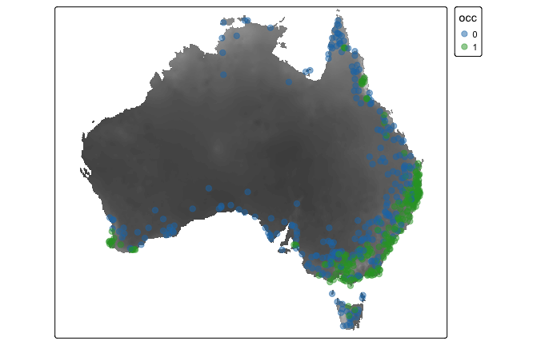

```r
tm_shape(rasters[[1]]) +
  tm_raster(
    col.scale = tm_scale_continuous(values = gray.colors(10)),
    col.legend = tm_legend_hide()
  ) +
  tm_shape(pa_data) +
  tm_dots(
    fill = "occ",
    fill.scale = tm_scale_categorical(),
    size = 0.5,
    fill_alpha = 0.5
  )
```

## Block cross-validation strategies

The `blockCV` stores training and testing folds in a common list format: `folds_list`, a list of the indices of observations in each fold. For k-fold methods that assign each observation to one fold, the folds are also stored as `folds_ids`, a vector of fold numbers for each observation, and often as `biomod_table`, a matrix suitable for the `biomod2` package. Use the format that suits your modelling workflow.

### Spatial blocks

The function `cv_spatial` creates spatial blocks/polygons then assigns blocks to the training and testing folds with *random*, *checkerboard pattern* or a *systematic* way (with the selection argument). When `selection = "random"`, the function tries to find evenly distributed records in training and testing folds. Spatial blocks can be defined either by `size` or number of rows and columns.

Consistent with other functions, the distance (`size`) should be in **metres**, regardless of the unit of the reference system of the input data. When the input map has *geographic coordinate system* (i.e. decimal degrees), the block size is calculated based on dividing `size` by 111325 (the standard distance of a degree in metres, on the Equator) to change metre to degree. In reality, this value varies by a factor of the cosine of the latitude. So, an alternative sensible value could be `cos(mean(sf::st_bbox(x)[c(2,4)]) * pi/180) * 111325`.

The `offset` argument can be used to shift the spatial position of the blocks in horizontal and vertical axes, respectively. This only works when the block have been built based on `size`, and the `extend` option allows user to enlarge the blocks ensuring all points fall inside the blocks (most effectve when `rows_cols` is used). The blocks argument allows users to define an external spatial polygon as blocking layer.

Here are some spatial block settings:

```r
sb1 <- cv_spatial(x = pa_data,
                  column = "occ", # the response column (binary or multi-class)
                  k = 5, # number of folds
                  size = 350000, # size of the blocks in metres
                  selection = "random", # random blocks-to-fold
                  iteration = 50, # find evenly dispersed folds
                  biomod2 = TRUE) # also create folds for biomod2
```

The output object is an R S3 object and you can get its elements by a `$`. Explore `sb1$folds_ids`, `sb1$folds_list`, and `sb1$biomod_table` for the three types of generated folds from the `cv_spatial` object `sb1`. Use the one suitable for you modelling practice to evaluate your models. See the explanation of all other outputs/elements of the function in the help file of the function.

The default spatial blocks are hexagons, and you can make this explicit with `hexagon = TRUE`. You can optionally add a raster layer (using `r` argument) to be used for creating blocks and in the background of the plot (a raster can also be added later only for visualising blocks using `cv_plot`).

```
##
##   train_0 train_1 test_0 test_1
## 1     211     193     46     50
## 2     197     200     60     43
## 3     218     205     39     38
## 4     195     199     62     44
## 5     207     175     50     68
```

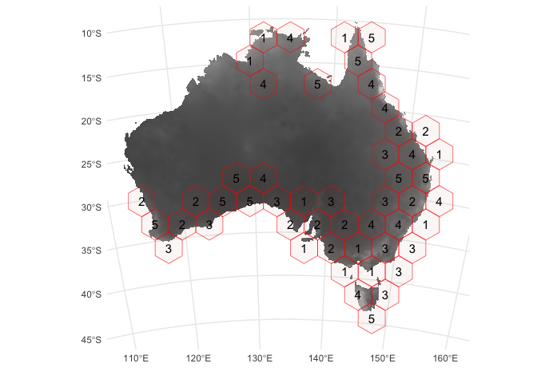

```r
sb2 <- cv_spatial(x = pa_data,
                  column = "occ",
                  r = rasters, # optionally add a raster layer
                  k = 5,
                  size = 350000,
                  hexagon = TRUE, # use hexagonal blocks
                  selection = "random",
                  progress = FALSE, # turn off progress bar for vignette
                  iteration = 50,
                  biomod2 = TRUE,
                  report = TRUE,
                  plot = TRUE)
```

The assignment of folds to each block can also be done in a systematic manner using `selection = "systematic"`, or a checkerboard pattern using `selection = "checkerboard"`. Square blocks are created with `hexagon = FALSE`, as shown below; checkerboard selection requires square blocks. The blocks can also be created by number of rows and columns when no `size` is supplied by e.g. `rows_cols = c(12, 10)`.

```
##
##   train_0 train_1 test_0 test_1
## 1     227     203     30     40
## 2     204     232     53     11
## 3     215     125     42    118
## 4     194     220     63     23
## 5     188     192     69     51
```

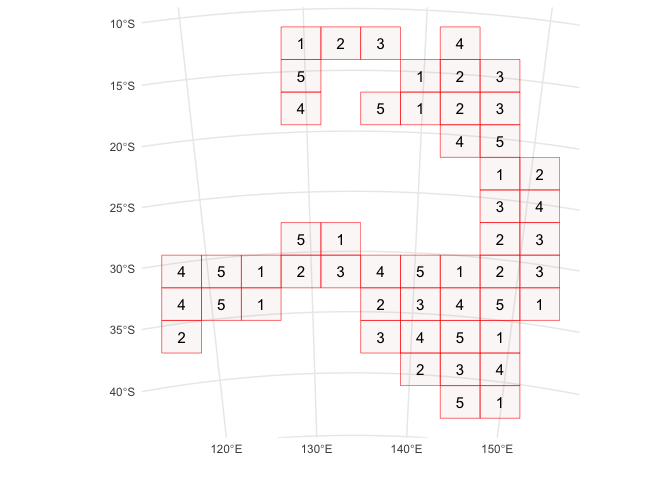

```r
# systematic fold assignment
# and also use row/column for creating blocks instead of size
sb3 <- cv_spatial(x = pa_data,
                  column = "occ",
                  rows_cols = c(12, 10),
                  hexagon = FALSE,
                  selection = "systematic",
                  report = TRUE,
                  plot = TRUE)
```

The function’s output report reveals that setting the selection to ‘random’ results in a more even distribution of presence/absence instances between the train and test folds compared to ‘systematic’. This is because the random assignment process is repeated multiple times, controlled by the `iteration` parameter, to ensure that the folds are evenly distributed.

```
##
##   train_0 train_1 test_0 test_1
## 1     125     143    132    100
## 2     132     100    125    143
```

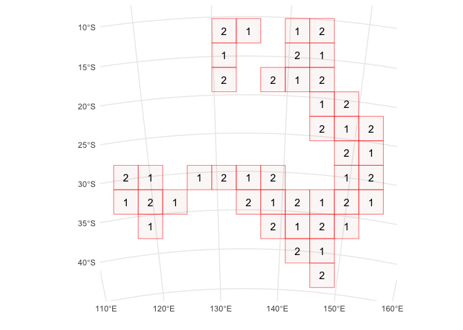

```r
# checkerboard block to CV fold assignment
sb4 <- cv_spatial(x = pa_data,
                  column = "occ",
                  size = 350000,
                  hexagon = FALSE,
                  selection = "checkerboard",
                  report = TRUE,
                  plot = TRUE)
```

Let’s visualise the checkerboard blocks with `tmap`:

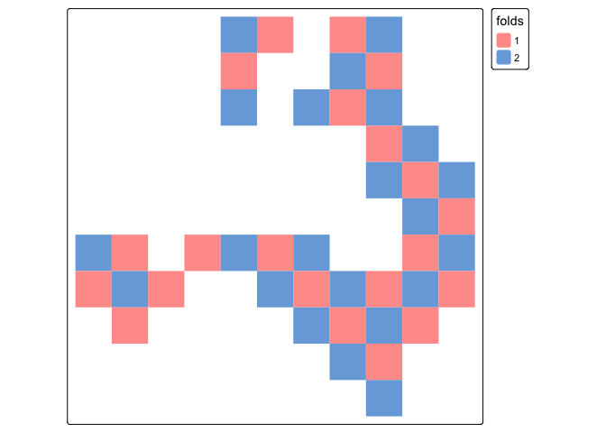

```r
tm_shape(sb4$blocks) +
  tm_fill(
    fill = "folds",
    fill.scale = tm_scale_categorical()
  )
```

### Spatial and environmental clustering

The function `cv_cluster` uses *clustering* methods to specify sets of similar environmental conditions based on the input covariates. Species data corresponding to any of these groups or clusters are assigned to a fold. Alternatively, the clusters can be based on spatial coordinates of sample points (the `x` argument).

Using spatial coordinate values for clustering:

```r
# spatial clustering
set.seed(6)
scv <- cv_cluster(x = pa_data,
                  column = "occ", # optional: counting number of train/test records
                  k = 5,
                  report = TRUE)
```

```
##   train_0 train_1 test_0 test_1
## 1     230     240     27      3
## 2     171     142     86    101
## 3     232     228     25     15
## 4     203     227     54     16
## 5     192     135     65    108
```

The default spatial clustering keeps each fold spatially compact, but the number of records or classes in each fold can be uneven. To prioritise more even folds, set `balance = TRUE`. In this case, `cv_cluster()` first creates `k * k_multiplier` smaller clusters and then assigns those clusters to `k` folds.

```r
# balanced spatial clustering
set.seed(6)
bscv <- cv_cluster(x = pa_data,
                   column = "occ",
                   k = 5,
                   balance = TRUE,
                   k_multiplier = 3,
                   report = TRUE)
```

```
##   train_0 train_1 test_0 test_1
## 1     219     180     38     63
## 2     199     206     58     37
## 3     203     202     54     41
## 4     214     192     43     51
## 5     193     192     64     51
```

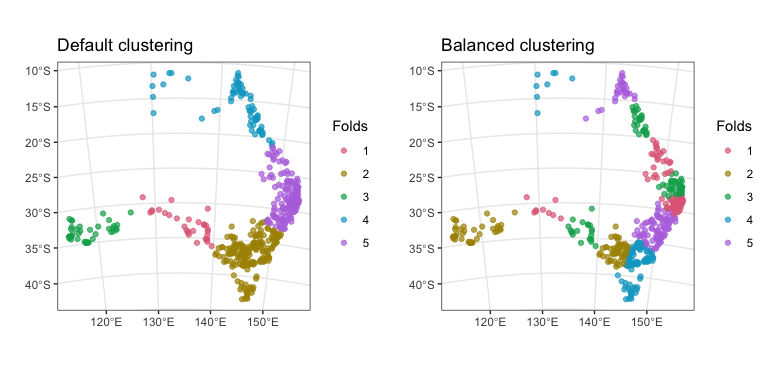

```r
scv_plot <- cv_plot(scv, pa_data, combine_folds = TRUE) +
    ggplot2::labs(title = "Default clustering")

bscv_plot <- cv_plot(bscv, pa_data, combine_folds = TRUE) +
    ggplot2::labs(title = "Balanced clustering")

cowplot::plot_grid(scv_plot, bscv_plot, nrow = 1)
```

Increasing `k_multiplier` usually improves the balance of records or classes across folds because there are more small clusters to assign, but it reduces the spatial separation and compactness of the final folds.

For species **presence-background** data (presences and background or pseudo-absence points), supply the response `column` and set `presence_bg = TRUE`. The fold balancing is then driven by the presence points (`1`s) only, so that the usually far more numerous background points do not dominate the split. This applies to the balancing in `cv_spatial`, `cv_cluster`, and `cv_knndm`. The example below uses the presence-background data supplied with the package in `species_pb.csv`.

```r
# load species presence-background data and convert to sf
points_pb <- read.csv(system.file("extdata/", "species_pb.csv", package = "blockCV"))
pb_data <- sf::st_as_sf(points_pb, coords = c("x", "y"), crs = 7845)

# balance folds on presences only (presence-background data)
set.seed(6)
pbcv <- cv_cluster(x = pb_data,
                   column = "occ",
                   k = 5,
                   balance = TRUE,
                   presence_bg = TRUE, # balance on presences (1s) only
                   report = TRUE)
```

```
##   train_0 train_1 test_0 test_1
## 1    8056     194   1944     49
## 2    7965     194   2035     49
## 3    8063     220   1937     23
## 4    7952     219   2048     24
## 5    7964     145   2036     98
```

The clustering can be done in environmental space by supplying `r`. Notice, this could be an extreme case of cross-validation as the testing folds could possibly fall in novel environmental conditions compared with the training points. Tutorial 2 shows how to check this with `cv_similarity`. Note that the input raster layer should cover all the species points, otherwise an error will rise. The records with no raster value should be deleted prior to the analysis or a different raster be used.

```r
# environmental clustering
set.seed(6)
ecv <- cv_cluster(x = pa_data,
                  column = "occ",
                  r = rasters,
                  k = 5,
                  scale = TRUE)
```

When `r` is supplied, all the input rasters are first centred and scaled to avoid one raster variable dominate the clusters using `scale = TRUE` option.

By default, the clustering will be done based only on the values of the predictors at the sample points. In this case, and the number of the folds will be the same as `k`. If `raster_cluster = TRUE`, the clustering is done in the raster space. In this approach, the clusters will be consistent throughout the region and across species (in the same region). However, this may result in cluster(s) that cover none of the species records especially when species data is not dispersed throughout the region (or environmental ranges) or the number of clusters (`k` or folds) is high.

Purely environmental clusters can be scattered across the study area, since points with similar covariate values may be far apart in space. The `spatial_weight` argument (a number in `[0, 1]`) adds a soft spatial-compactness pressure by blending the coordinates into the environmental clustering: `spatial_weight = 0` (the default) is pure environmental clustering, larger values pull the clusters to be more geographically compact, and `spatial_weight = 1` clusters on the coordinates alone. A moderate value such as `0.4` keeps the folds environmentally coherent while making them more spatially separated.

```r
# spatially constrained environmental clustering
set.seed(6)
secv <- cv_cluster(x = pa_data,
                   column = "occ",
                   r = rasters,
                   k = 5,
                   scale = TRUE,
                   spatial_weight = 0.4) # blend geography into the environmental clusters
```

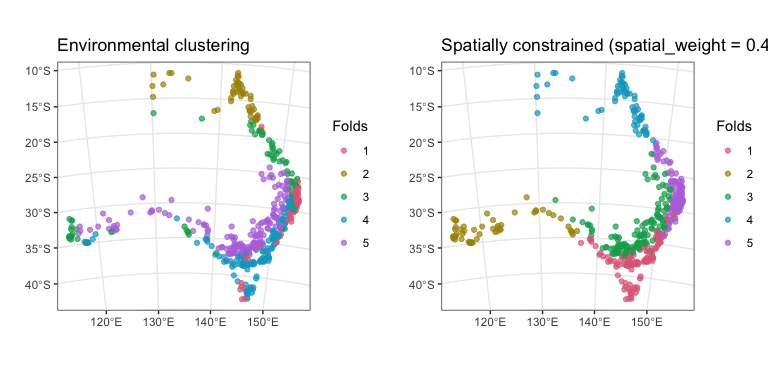

```r
ecv_plot <- cv_plot(ecv, pa_data, combine_folds = TRUE) +
    ggplot2::labs(title = "Environmental clustering")

secv_plot <- cv_plot(secv, pa_data, combine_folds = TRUE) +
    ggplot2::labs(title = "Spatially constrained (spatial_weight = 0.4)")

cowplot::plot_grid(ecv_plot, secv_plot, nrow = 1)
```

### Leave-group-out cross-validation

The function `cv_group` creates folds from an existing grouping column, such as a site, plot, sampling campaign, or individual identifier. Records that share a group are always kept together, so the same group never appears in both the training and testing set of a fold.

The package example data do not include a site identifier, so the next chunk creates an illustrative grouping column. In your own data, use the real grouping variable that defines the dependence structure you want to hold out.

```r
set.seed(6)
coords <- sf::st_coordinates(pa_data)
pa_data$site <- paste0("site_", stats::kmeans(coords, centers = 10)$cluster)
```

With `k = NULL` (the default), `cv_group()` performs leave-group-out cross-validation: each group is left out once.

```r
site_lgo <- cv_group(x = pa_data,
                     group_col = "site",
                     column = "occ",
                     report = TRUE)
```

```
##    train_0 train_1 test_0 test_1
## 1      230     206     27     37
## 2      238     239     19      4
## 3      224     240     33      3
## 4      233     239     24      4
## 5      238     231     19     12
## 6      235     202     22     41
## 7      220     205     37     38
## 8      231     240     26      3
## 9      232     228     25     15
## 10     232     157     25     86
```

If there are many groups, you can merge them into fewer folds by setting `k`. With `balance = TRUE`, the function searches for a group-to-fold assignment with more even record or class counts, while still keeping whole groups together.

```r
site_cv <- cv_group(x = pa_data,
                    group_col = "site",
                    column = "occ",
                    k = 5,
                    balance = TRUE,
                    iteration = 50,
                    seed = 6,
                    report = TRUE)
```

```
##   train_0 train_1 test_0 test_1
## 1     204     203     53     40
## 2     199     154     58     89
## 3     201     201     56     42
## 4     213     216     44     27
## 5     211     198     46     45
```

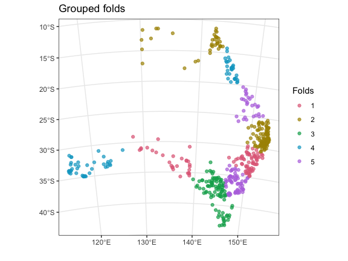

```r
cv_plot(site_cv, pa_data, combine_folds = TRUE) +
    ggplot2::labs(title = "Grouped folds")
```

### Buffering LOO (also known as Spatial LOO)

The function `cv_buffer` generates spatially separated training and testing folds by considering buffers of specified distance around each observation point. This approach is a form of leave-one-out (LOO) cross-validation. Each fold is generated by excluding nearby observations around each testing point within the specified distance (ideally the range of spatial autocorrelation). In this method the test set never directly abuts a training set.

Using buffering to create CV folds:

```r
bloo <- cv_buffer(x = pa_data,
                  column = "occ",
                  size = 350000)
```

When using species **presence-background** data (or presence and pseudo-absence), you need to supply the `column` and set `presence_bg = TRUE`. In this case, only presence points (1s) are considered as target points. For more information read the details section in the help of the function (i.e. `help(cv_buffer)`).

For species **presence-absence** data and any other types of data (such as **continuous**, **counts**, and **multi-class** targets) keep `presence_bg = FALSE` (default). In this case, all sample points other than the target point within the buffer are excluded, and the training set comprises all points outside the buffer.

## Nearest Neighbour Distance Matching (NNDM) LOO

The `cv_nndm` is a fast implementation of the Nearest Neighbour Distance Matching (NNDM) algorithm (Milà et al., 2022) in C++. Similar to `cv_buffer`, this is a variation of leave-one-out (LOO) cross-validation. It tries to match the nearest neighbour distance distribution function between the test and training data to the nearest neighbour distance distribution function between the target prediction and training points (Milà et al., 2022).

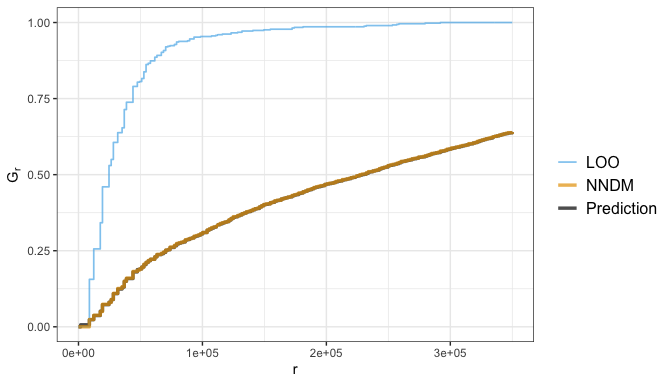

```r
nncv <- cv_nndm(x = pa_data,
                column = "occ",
                r = rasters,
                size = 350000,
                num_sample = 5000,
                sampling = "random",
                min_train = 0.1,
                plot = TRUE)
```

## k-fold Nearest Neighbour Distance Matching (kNNDM)

The `cv_knndm` function implements the k-fold version of NNDM (Linnenbrink et al., 2024). Unlike `cv_nndm`, it returns a smaller set of `k` folds, making it cheaper to fit models while still matching the nearest neighbour distance distribution between testing and training data to the prediction-to-training distribution.

The original kNNDM grouping options are `clustering = "hierarchical"` and `clustering = "kmeans"`. The example below uses hierarchical clustering; use `clustering = "kmeans"` for the k-means alternative. For a quick vignette run, the examples use `num_sample = 5000` and `nk_len = 50`; for applied analyses, consider using the defaults or larger values, especially for large prediction areas or complex sampling patterns.

```
##   train_0 train_1 test_0 test_1
## 1     233     151     24     92
## 2     209     177     48     66
## 3     200     195     57     48
## 4     201     224     56     19
## 5     185     225     72     18
```

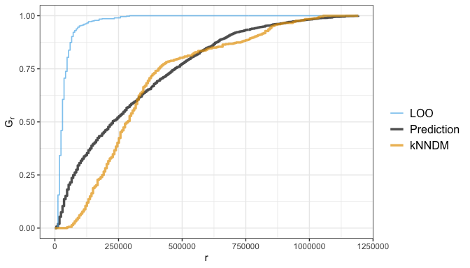

```r
knn_hier <- cv_knndm(x = pa_data,
                     column = "occ",
                     r = rasters,
                     k = 5,
                     clustering = "hierarchical",
                     num_sample = 5000,
                     nk_len = 50,
                     seed = 6,
                     report = TRUE,
                     plot = TRUE)
```

The default `clustering = "blocks"` option is specific to `blockCV`. It first groups sample points with spatial blocks (hexagonal by default, or square with `hexagon = FALSE`) and then allocates those groups to kNNDM folds.

```
##   train_0 train_1 test_0 test_1
## 1     176      84     81    159
## 2     201     192     56     51
## 3     187     227     70     16
## 4     243     240     14      3
## 5     221     229     36     14
```

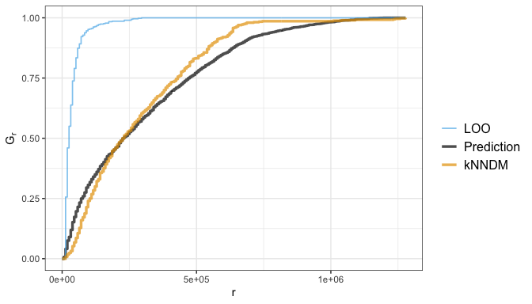

```r
knn_blocks <- cv_knndm(x = pa_data,
                       column = "occ",
                       r = rasters,
                       k = 5,
                       clustering = "blocks",
                       keep_blocks = TRUE,
                       num_sample = 5000,
                       nk_len = 50,
                       seed = 6,
                       report = TRUE,
                       plot = TRUE)
```

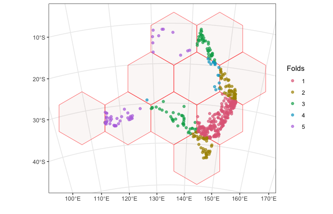

```r
cv_plot(knn_blocks, pa_data, combine_folds = TRUE)
```

## Visualising the folds

You can visualise the generate folds for all block cross-validation strategies. You can optionally add a raster layer as background map using `r` option. When `r` is supplied the plots might be slightly slower.

The output of `cv_plot()` is a `ggplot` object, so it can be customised with standard `ggplot2` layers. For example, you can add a title, change the theme, or modify colours and scales.

Let’s plot spatial clustering folds created in previous section (using `cv_cluster`):

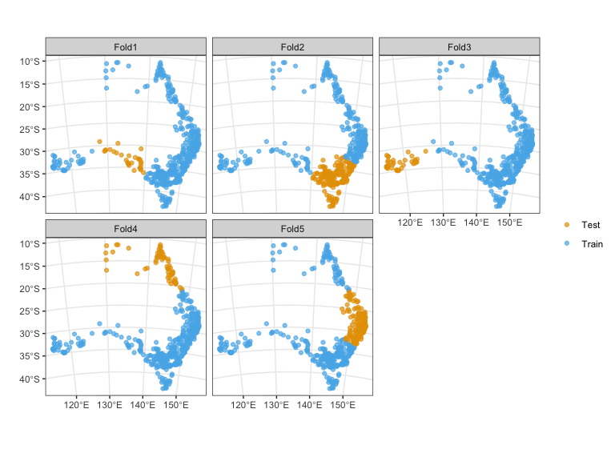

```r
cv_plot(cv = scv, x = pa_data)
```

Optionally, all folds can be plotted in a single panel, with colours indicating different folds. This option is available for k-fold cross-validation methods: `cv_spatial`, `cv_cluster`, `cv_group`, and `cv_knndm`.

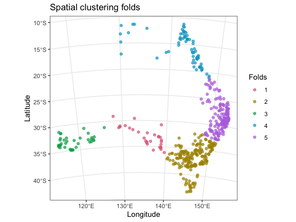

```r
cv_plot(cv = scv, x = pa_data, combine_folds = TRUE) +
    ggplot2::labs(
        title = "Spatial clustering folds",
        x = "Longitude",
        y = "Latitude"
    )
```

When the fold object was built with `presence_bg = TRUE`, `cv_plot()` draws the background points (`0`s) faded so the presences (`1`s) stand out. The background opacity is set with `bg_alpha`; it is capped at `points_alpha` so the background is never more prominent than the presences (set `bg_alpha = points_alpha` to disable the fading).

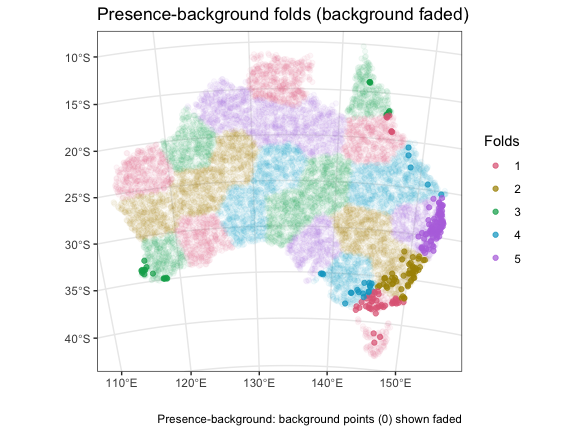

```r
cv_plot(cv = pbcv, x = pb_data, combine_folds = TRUE, bg_alpha = 0.05) +
    ggplot2::labs(title = "Presence-background folds (background faded)")
```

When `cv_buffer` is used for plotting, only first 10 folds are shown. You can choose any set of CV folds for plotting. If `remove_na = FALSE` (default is `TRUE`), the `NA` in the legend shows the excluded points.

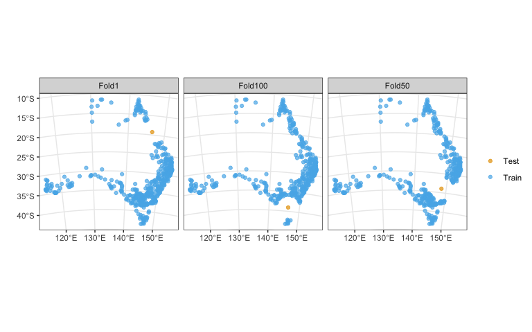

```r
cv_plot(cv = bloo,
        x = pa_data,
        num_plots = c(1, 50, 100)) # only show folds 1, 50 and 100
```

If you do not supply `x` when plotting a `cv_spatial` object, only the spatial blocks are plotted.

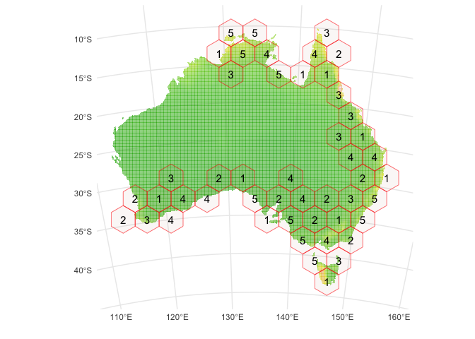

```r
cv_plot(cv = sb1,
        r = rasters,
        raster_colors = terrain.colors(10, alpha = 0.5),
        label_size = 4)
```

## Next steps

After creating folds, use Tutorial 2 (open with `vignette("tutorial_2", package = "blockCV")`) to check fold size balance, environmental novelty, nearest-neighbour distance matching, and candidate spatial block sizes.

## References:

- Linnenbrink, J., Milà, C., Ludwig, M., & Meyer, H. (2024) kNNDM CV: k-fold nearest neighbour distance matching cross-validation for map accuracy estimation. Geoscientific Model Development, 17(15), 5897–5912. [doi: 10.5194/gmd-17-5897-2024](https://doi.org/10.5194/gmd-17-5897-2024)
- Milà, C., Mateu, J. , Pebesma, E. and Meyer H. (2022) Nearest Neighbour Distance Matching Leave-One-Out Cross-Validation for map validation. Methods in Ecology and Evolution.
- Valavi R, Elith J, Lahoz-Monfort JJ, Guillera-Arroita G. (2019) **blockCV: An R package for generating spatially or environmentally separated folds for k-fold cross-validation of species distribution models**. *Methods Ecol Evol.* 10:225–232. [doi: 10.1111/2041-210X.13107](https://doi.org/10.1111/2041-210X.13107)